# Learning ggplot2 Worksheet

Breakout Group

2022-09-05

## Directions

Work with one or more other students to complete each of the tasks in this document. As you work through these tasks, you may want to refer to the following:

- [Visualizing Data with ggplot2](https://zief0002.github.io/toolkit-quarto/06-visualizing-with-ggplot2.html)

As part of this, include the syntax you use to complete each tasks in a script file. As you write your script file, adhere to good coding practices:

- Include comments
- Include spaces
- Include a line break after every pipe operator you use.

You can check in with Andy or the TA at the completion of each task to check your work.

## Task 1: Import Data

Import the riverview.csv data into an object named `city`. Also, examine the [data codebook](https://zief0002.github.io/miniature-garbanzo/codebooks/riverview.html) so you are familiar with the different attributes.

## Task 2: Sketch

Make a rough sketch of the plot you think this syntax will produce. Try not to run the syntax until you create a sketch. After you have created your rough sketch, run the syntax to check your work.

```r
ggplot(data = city, aes(x = education, y = income)) +
  geom_point() +
  xlab("Education level (in years)") +
  ylab("Annual income (in U.S. dollars)") +
  theme_bw()
```

## Task 3: Mimic a Plot

Write syntax to create the following plot, which was created using the `city` (riverview) data. Write this syntax in a script file. Be sure you are using good coding practices and putting each layer on a different line. (Hint: If you want to be exact, use [Tin Eye Lab’s Color Extraction tool](https://labs.tineye.com/color/) to extract the hex codes for the color.)

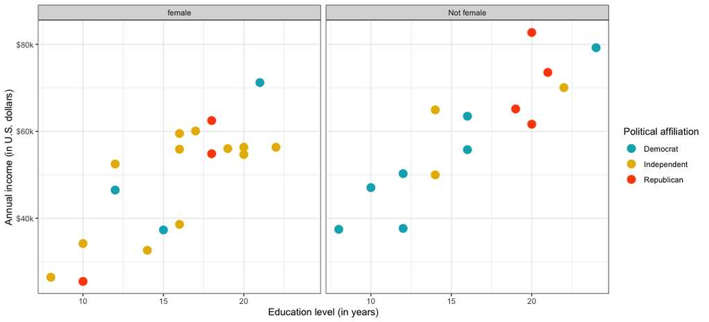

## Task 4: Export a Plot and Import it into a Document

Export the plot you created in Task 3 as a PNG file. Be sure the aspect ratio of the plot is reasonable (the plot is not scrunched or stretched). Import the exported PNG file into a word-processed document. Re-size the plot so that it is not taking up excess space in the document, and also still readable. Add a figure number and caption to your plot.

## Task 5: Mimic a Plot

Write syntax to create the following plot, which was created using the `city` (riverview) data. Write this syntax in a script file. Be sure you are using good coding practices and putting each layer on a different line.

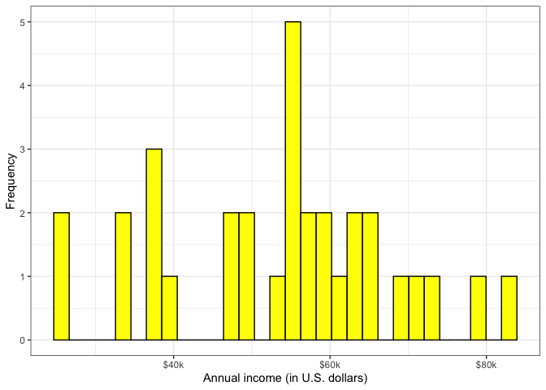

## Task 6: Mimic a Plot

Write syntax to create the following plot, which was created using the gapminder.csv data. Write this syntax in a script file. Be sure you are using good coding practices and putting each layer on a different line.

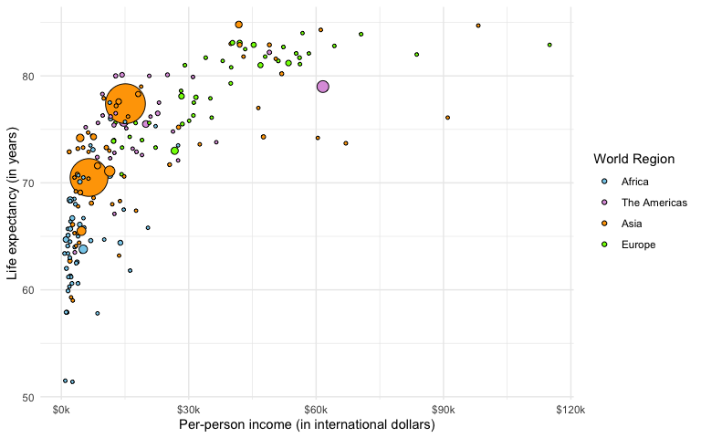

Life expectancy versus per-peron income for 193 countries. The size of the observations is based on population.

## Task 7: Add Text to Label a Point

Add text to the plot you created in Task 6 tolabel the country with the highest life expectancy.